# Stat. 652 Homework01

Rohit Shelar

February 05, 2021

- **Read:** Chapter 7
- **Problems:** Chapter 7 Exercises 7.1, 7.2, 7.5, 7.6 (2e 9.9 Exercises, Problem 2, Problem 3, 9.10 Supplemental exercises, Problem 2a, Problem 2b)

**Instructions:** Answer all questions in the space below the # headers.

# Problem 7.1, 2e 9.9 Exercises, Problem 2

Calculate and interpret a 95% confidence interval for the mean age of mothers from the `Gestation` data set from the `mosaicData` package.

### **Answer:**

The Gestation data set from mosaiData package has total 1236 data points of which 2 entries are empty in required ‘age’ column. Hence after removing ‘null’ entries, we are left with 1234 data points to work on.

The code below explores 3 ways of finding 95% Confidence Interval:

- Traditional calculation of standard error and confidence interval
- Using Rmisc Package
- Using t-test

Here are the findings :

Age Size before removing Null values: 1236

Sample Size/Age Size after removing Null values: 1234

Standard Error: 0.322886922065767

95% Confidence interval for population mean:

- Mean Age: 27.2552674230146
- Lower Confidence Interval: 26.9323805009488
- Upper Confidence Interval: 27.5781543450804

Please reference to code and comments as well as output windows.

### **Code and Comments:**

```r
library(Rmisc)
```

```r
# "Loading - data <- mosaicData::Gestation"
data <- mosaicData::Gestation
head(data, 3)
```

```
##   id     pluralty    outcome       date gestation  sex  wt parity  race age
## 1 15 single fetus live birth 1964-11-11       284 male 120      1 asian  27
## 2 20 single fetus live birth 1965-02-07       282 male 113      2 white  33
## 3 58 single fetus live birth 1965-04-25       279 male 128      1 white  28
##                                ed ht wt.1 drace dage
## 1                College graduate 62  100 asian   31
## 2                College graduate 64  135 white   38
## 3 HS graduate--no other schooling 64  115 white   32
##                                  ded dht dwt marital         inc smoke
## 1                   College graduate  65 110 married   2500-5000 never
## 2                   College graduate  70 148 married 10000-12500 never
## 3 8th -12th grade - did not graduate  NA  NA married   5000-7500   now
##           time      number
## 1 never smoked       never
## 2 never smoked       never
## 3 still smokes 1-4 per day
```

```r
# Data cleaning steps
age <- data$age
message("Age Size before removing Null values: ", length(age))
```

```
## Age Size before removing Null values: 1236
```

```r
age <- age[!is.na(age)]

# Calculating mean, standard deviation and sample size
mean_age <- mean(age)
std_age <- sd(age)
sample_size <- length(age)

message("Sample Size/Age Size after removing Null values: ", sample_size)
```

```
## Sample Size/Age Size after removing Null values: 1234
```

```r
message("-----------------------------------------------------")
# Calculating standard error and 95% confidance intervals (upper and lower)

error <- qt(0.975, sample_size-1)* std_age/sqrt(sample_size)
message("Standard Error: ",error)
```

```
## Standard Error: 0.322886922065767
```

```r
lower_ci <- mean_age - error
upper_ci <- mean_age + error

message("95% Confidence Interval for population mean:")
```

```
## 95% Confidence Interval for population mean:
```

```r
message("Mean Age: ", mean_age)
```

```
## Mean Age: 27.2552674230146
```

```r
message("Lower Confidence Interval: ", lower_ci)
```

```
## Lower Confidence Interval: 26.9323805009488
```

```r
message("Upper Confidence Interval: ", upper_ci)
```

```
## Upper Confidence Interval: 27.5781543450804
```

```r
message("-----------------------------------------------------")
```

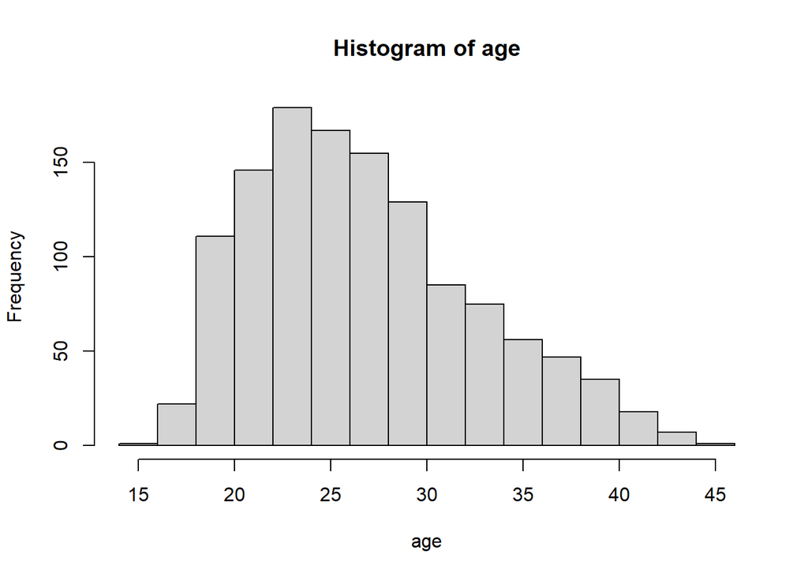

```r
#histogram Visualization
hist(age)
```

```r
#Calculating Confidance Interval using CI function from Rmisc package.
message("95% Confidence interval for population mean Using Rmisc Package:")
```

```
## 95% Confidence interval for population mean Using Rmisc Package:
```

```r
CI(age, ci=0.95)
```

```
##    upper     mean    lower
## 27.57815 27.25527 26.93238
```

```r
message('-----------------------------------------------------')
message("95% Confidence Interval using T Test:")
```

```
## 95% Confidence Interval using T Test:
```

```r
t.test(age, mu = mean_age, alternative ="two.sided", conf.level = 0.95)
```

```
##
##  One Sample t-test
##
## data:  age
## t = 0, df = 1233, p-value = 1
## alternative hypothesis: true mean is not equal to 27.25527
## 95 percent confidence interval:
##  26.93238 27.57815
## sample estimates:
## mean of x
##  27.25527
```

# Problem 7.2, 2e 9.9 Exercises, Problem 3

Use the bootstrap to generate and interpret a 95% confidence interval for the median age of mothers for the `Gestation` data set from the `mosaicData` package.

### **Answer:**

for using bootstrap method to interpret confidence interval we will resample the population 100000 times by sampling the dataset with replacement. As different coding techniques to calculate confidence interval are demonstrated in first problem, I’ll be using Rmisc package to calculated 95% CI.

Note; as we have to interpret 95% CI for Median, we will take medians for all the samples we generate and calculated CI for medians of samples.

( ————–

I would like to take this opportunity to demonstrate effect of different sample size.

Please refer to 4 histograms measured for sample size of 30, 100, 500 and 1234 which is True sample size of dataset.

Standard error decreases when sample size increases. As sample size comes more and more closer to true size of population population; the sample mean or median measures comes more closer to True measures of population.

————- )

Below is the results:

Mean Age of Sample : 27.25527

Median Age of Sample : 26

Number of replications = 100000

Sample Size = 1234 = length(age)

### **Code and Comments:**

```r
dataList=list(30,100,500,length(age))
cat("Mean Age : ", mean(age),'\n')
```

```
## Mean Age :  27.25527
```

```r
cat("Median Age : ", median(age),'\n\n')
```

```
## Median Age :  26
```

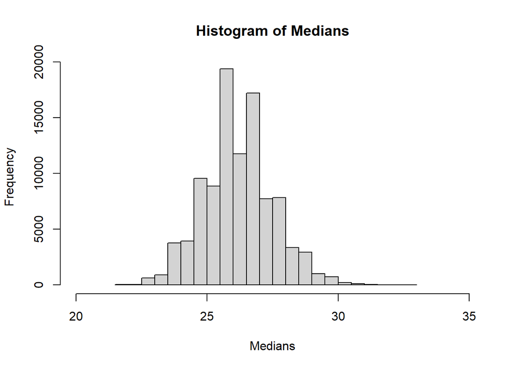

```
##
## 95% Confidence Interval at sample size :  30
##
##    upper     mean    lower
## 26.44753 26.43925 26.43097
## -------------------------------------------------------------
```

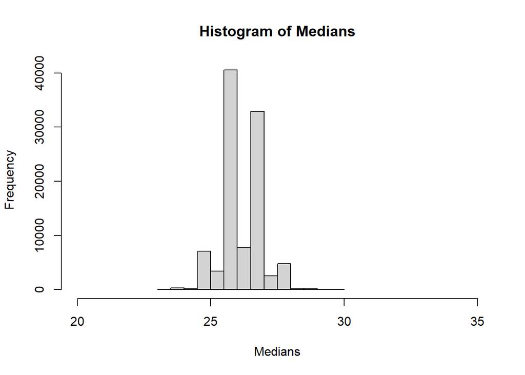

```
##
## 95% Confidence Interval at sample size :  100
##
##    upper     mean    lower
## 26.42017 26.41555 26.41093
## -------------------------------------------------------------
```

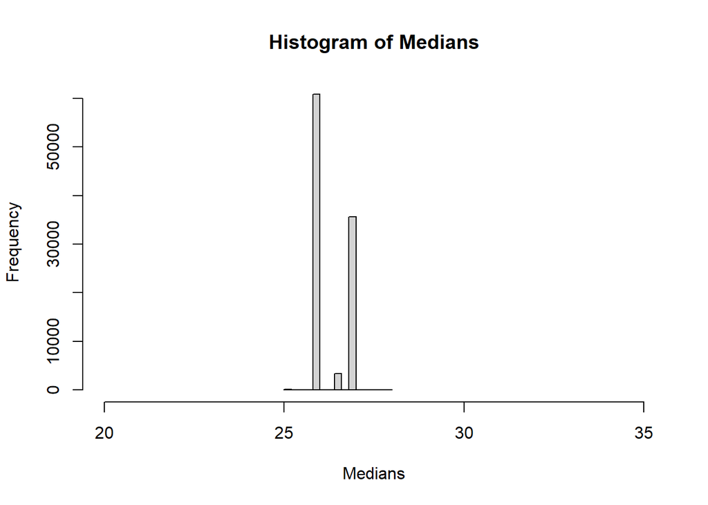

```
##
## 95% Confidence Interval at sample size :  500
##
##    upper     mean    lower
## 26.37518 26.37222 26.36926
## -------------------------------------------------------------
```

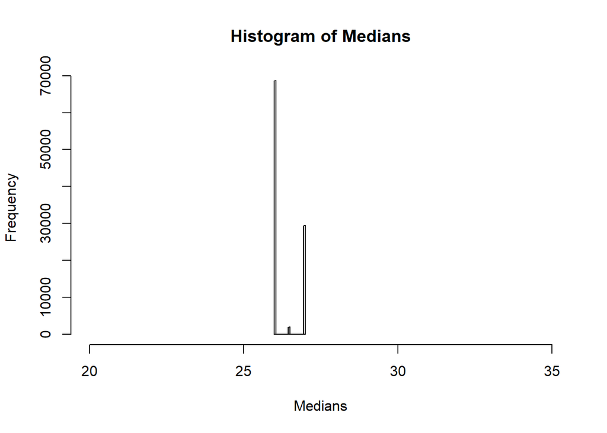

```
##
## 95% Confidence Interval at sample size :  1234
##
##    upper     mean    lower
## 26.30716 26.30434 26.30152
## -------------------------------------------------------------
```

```r
set.seed(1234)

for(i in dataList)
  {
  Medians = replicate(n = 100000, median(sample(age, size = i, replace = TRUE)))

  hist(Medians, xlim=c(20,35))
  cat("\n95% Confidence Interval at sample size : ", i,'\n\n')
  print(CI(Medians, ci=0.95))
  cat("-------------------------------------------------------------\n")
  }
```

# Problem 7.5, 2e 9.10 Supplemental exercises, Problem 2a

Consider the results from the model of `Dist` as a function of `Cond` (first model). Briefly summarize what this model says about the relationship between the wind conditions and the distance travelled by the ball. Make sure to say something sensible about the strength of evidence that there is any relationship at all.

### **Answer:**

With reference to first model:

The intercept value shows an average distance 350.768 feet by a fly ball. CondTail i.e slop value is about 5.865 which indicates a unit change in distance traveled by fly ball, which is not so much for a mean travel distance of 350.768 feet. Adding to which Standard error of 3.281 is quite significant for slop coefficient 5.865 value.

When we look at the 0.0833; P-Value for the model’s estimation, although it is close to 0.05, it’s not statistically significant to reject the null hypothesis i.e There is no relationship between distance traveled and condition measures.

Thus, the null hypothesis stays for the estimated results by first model. Having said that, Adjusted R square value of 0.06239 does not really give confidence in model’s prediction, hence better sample size and fine tuning the model’s might help to understand the relationship better.

### **Code and Comments:**

```r
# The problem does not demand coding
```

# Problem 7.6, 2e 9.10 Supplemental exerises, Problem 2b

Briefly summarize the model that has `Dist` as the response variable and includes the other variables as explanatory variables (second model) by reporting and interpreting the `CondTail` parameter. This second model suggests a somewhat different result for the relationship between `Dist` and `Cond`. Summarize the differences and explain in statistical terms why the inclusion of the other explanatory variables has affected the results.

### **Answer:**

Adding more independent variables to measure effect on distance attribute does work. And we see significant positive change in model performance. The overall adjusted R square of 0.5188 in comparison of first models adjusted R square value of i.e 0.06239 is pretty significant. F-Statistic value at level of 8.115 gives positive sight for model performance. At P-Value of 7.81e-05, it is statistically significant to reject the null hypothesis; and we can conclude that there is relationship between dependent variable ‘distance’ and other predictors.

Besides; when we look at individual say of independent predictors. it can be found that ‘Angle’ and ‘BallWt’ does not show statistical significance. Where as BallDia, Velocity and CondTail are statistically significant.

While comparing the CondTail’s impact individually in first model and second model; a strange pattern can be observed. Individually it was insignificant but in combination of other independent variables at P-value of 0.00418 is looks statistically significant.

This is problem of multicollinearity, where independent predictors share some kind of collinearity among themselves. to understand better, we have to explore the data further and visualize the correlation between the variables.

To address the issue we can find highly (ex: 90% or more) correlated features and drop one of the features. Dropping features can also be looked as loosing the information. Better way to address the issue is using regularization techniques such as Ridge and Lasso Regression.

### **Code and Comments**

```r
# The problem does not demand coding
```